# Aprendizado de Máquina

### Gabriel Sanfins

#### `gabrielsanfins@id.uff.br`

### 01 - Introdução

# Sobre o curso

## Bibliografia

- [ISLP] Gareth James, Daniela Witten, Trevor Hastie, Rob Tibshirani & Jonathan Taylor - *An Introduction to Statistical Learning, with Applications in Python*
  - Disponível [on-line](https://www.statlearning.com/)
- [AME] Rafael Izbicki & Tiago Mendonça dos Santos - *Aprendizado de Máquina: Uma Abordagem Estatística*
  - Disponível [on-line](https://rafaelizbicki.com/ame/)
- Eventuais referências adicionais (artigos, livros, etc.)

## Conteúdo programático

- Capítulos 1 até 9, e 12 (aproximadamente) de [ISLP]
  - Mais ou menos equivalente aos Capítulos 1, 2, 3, 7, 8, 9, 10 e 11 (aproximadamente) de [AME]

## Sistema de avaliação

- 2 provas e 1 projeto
  - Questões teóricas e dissertativas
  - Resolução de problemas práticos
- Postagem e data de entrega no cronograma
  - O cronograma da disciplina encontra-se no Google Classroom

# O que é *machine learning*/aprendizado estatístico/aprendizado de máquina?

[figure not shown]

Retirado de https://xkcd.com/1838/

[figure not shown]

Retirado de https://xkcd.com/2494/

- Estatística
  - “Disciplina que trata da coleta, organização, análise, interpretação e apresentação de dados”. [Fonte: [Wikipedia](https://en.wikipedia.org/wiki/Statistics)]
- Aprendizado estatístico/*Machine Learning*
  - Conjunto de ferramentas e modelos para entender dados, com especial atenção a aspectos de eficiência computacional. [Fonte: [Wikipedia](https://en.wikipedia.org/wiki/Machine_learning) + vozes da minha cabeça]

## Porque tal distinção é necessária?

- Nascimento da Estatística na cultura européia
  - Mínimos quadrados, Gauss e Legendre ≈ 1800, prever órbitas ao redor do Sol
  - Equivalente ao EMV para regressão, assumindo erro normalmente distribuído
- Avanços nos sistemas de captura, armazenamento e processamento de dados permitem analisar grandes bases de dados

## Porque tal distinção é necessária?

[figure not shown]

http://millionsongdataset.com/ - base de dados com 280 Gb.

## Porque tal distinção é necessária?

- Métodos tradicionais de Estatística não são mais capazes de lidar com esse volume de dados
- Dados complexos: um bom entendimento sobre a aplicação não é somente importante mas crucial, em particular, para a elaboração de novas metodologias
- Em particular, metodologias e algoritmos podem ser fortemente dependentes da aplicação

## Mudança de paradigma

- Estatística do Séc. XX:
  - Resultados assintóticos
  - $n \gg p$, onde $n$ é o número de observações e $p$ é o número de covariáveis
- Aplicações modernas:
  - $p \gg n$ – ou seja, mais coisas para se estimar do que se observa!
  - Resultados assintóticos não se aplicam mais

## Duas culturas

- Modelagem dos dados: criação e validação de um modelo para os dados observados. Foco em inferência
- Modelagem algorítmica: criação de bons algoritmos para prever novas instâncias observadas. Muitas vezes não lança mão de modelo probabilístico algum para os dados ◄
- “Nem melhor nem pior, apenas diferentes!”

## Duas grandes áreas

- Aprendizado supervisionado: modelos para aprender uma relação entre uma entrada e uma saída com base em um conjunto de exemplos ◄
- Aprendizado não-supervisionado: algoritmos que aprendem padrões/estruturas subjacentes em dados não-anotados ◄

## Dois principais tipos de problemas

- Regressão: variável de saída é quantitativa ◄
- Classificação: variável de saída é categórica ◄

## Algumas verdades

- Aprendizado de Máquina **não** é a solução para todos os problemas do mundo
- Redes neurais também **não** são a solução para todos os problemas do mundo
- Aprender a usar os pacotes do Python/R **não** é aprender Aprendizado de Máquina
- Você **não** tem como aprender Aprendizado de Máquina sem dominar: cálculo, probabilidade, estatística e álgebra linear
- Quem te diz o contrário está **mentindo para você**

[figure not shown]

# Formulação matemática do problema do aprendizado estatístico supervisionado

## Formulação matemática

- $Y \in \mathbb{R}$ variável de resposta
- $\mathbf{X} = (X_1, \dots, X_p) \in \mathbb{R}^p$ conjunto de $p$ preditores para $Y$

## Formulação matemática

- Forma geral da relação entre $\mathbf{X}$ e $Y$:
  $$Y = r(\mathbf{X}) + \varepsilon$$
  - $r$ função fixa porém desconhecida
  - Informação sistemática que $\mathbf{X}$ dá sobre $Y$
  - $\varepsilon$ erro de observação (independente de $\mathbf{X}$ e de média zero)

## Formulação matemática

- **Objetivos**: Estimar $r$ a partir de um conjunto de observações $(\mathbf{x}_i, y_i)_{i = 1, \dots, n}$, bem como aferir a *qualidade* de tal estimativa
- **Importante**: Assumiremos observações i.i.d., ou seja, $(\mathbf{X}_1, Y_1), \dots, (\mathbf{X}_n, Y_n) \sim (\mathbf{X}, Y)$
  - O que **não** significa que a distribuição conjunta entre $\mathbf{X}$ e $Y$ será conhecida!
  - Em um mundo ideal, temos $r(\mathbf{x}) = \mathbb{E}[Y | \mathbf{X} = \mathbf{x}]$
- $Y$ quantitativa: problema de *regressão*
- $Y$ qualitativa: problema de *classificação*

## Um exemplo

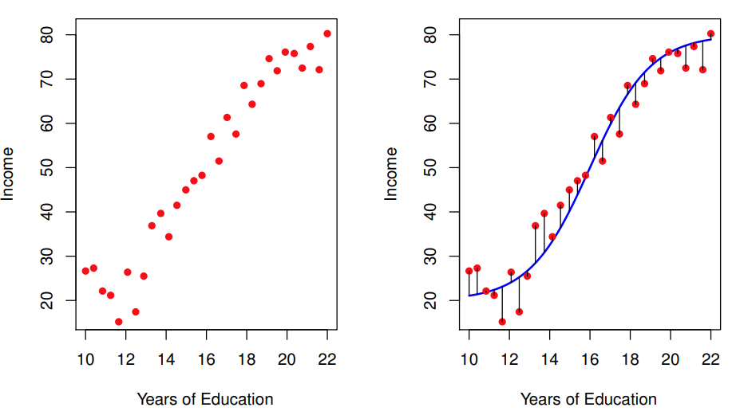

Figura 2.2 de [ISLP]

## Um exemplo

- Renda anual em função dos anos de estudo
- Uma estimativa da função $r(\mathbf{x}) = \mathbb{E}[Y | \mathbf{X} = \mathbf{x}]$ relacionando ambas as quantidades.
  - Usar $r$ para prever a renda com base no tempo de formação – *previsão*
  - Usar $r$ para testar hipóteses sobre a relação entre tais variáveis – *inferência*

## Mais sobre as duas culturas

- **Objetivo inferencial**: Quais preditores são importantes? Qual a relação entre cada preditor e a variável resposta? Qual o efeito da mudança de valor de um dos preditores na variável resposta?

## Mais sobre as duas culturas

- **Objetivo preditivo**: Como podemos criar uma função
  $$g: \mathbb{R}^p \to \mathbb{R}$$
  que tenha *bom poder preditivo*? Isto é, como criar $g$ tal que, dadas *novas* observações i.i.d.
  $$(\mathbf{X}_{n + 1}, Y_{n + 1}), \dots, (\mathbf{X}_{n + m}, Y_{n + m}) \sim (\mathbf{X}, Y)$$
  tenhamos
  $$g(\mathbf{x}_{n + 1}) \approx y_{n + 1}, \dots, g(\mathbf{x}_{n + m}) \approx y_{n + m}?$$

## Mais sobre as duas culturas

- Em um problema de regressão com **objetivo inferencial**, assumimos que alguma forma geral da função $r$ é verdadeira, por exemplo
  $$r(\mathbf{x}) = \beta_0 + \sum_{i = 1}^{p} \beta_i x_i.$$
  - Interpretação dos parâmetros estimados $\beta_i$
  - Testes de hipótese e intervalos de confiança
  - $\Rightarrow$ necessidade de se verificar hipóteses como normalidade dos erros, homocedasticidade, etc.

## Mais sobre as duas culturas

- Com **objetivo preditivo** não há nem porque assumir um modelo probabilístico subjacente, nem uma forma geral verdadeira para $r$.
  - Como encontrar o “melhor” preditor?

## A função risco

Critério para medir o desempenho de uma dada função de predição $g: \mathbb{R}^p \to \mathbb{R}$

- $(\mathbf{X}, Y)$ nova observação que **não** foi usada para se encontrar $g$
- $L(g; (\mathbf{X}, Y))$ – função *perda*
  - $L(g; (\mathbf{X}, Y)) = (Y - g(\mathbf{X}))^2$ – perda *quadrática*
  - $L(g; (\mathbf{X}, Y)) = |Y - g(\mathbf{X})|$ – perda *absoluta*
  - muitas outras…

## A função risco

- Tirando a dependência na observação específica…
  - $R_{\mathrm{pred}}(g) = \mathbb{E}[L(g; (\mathbf{X}, Y))]$
  - No caso da perda quadrática (usual em regressão)
    $$R_{\mathrm{pred}}(g) = \mathbb{E}[(Y - g(\mathbf{X}))^2]$$

## A importância da perda quadrática

- Medir a performance de um estimador com base em seu risco quadrático
- São equivalentes:
  - Criar uma “boa” função de predição $g: \mathbb{R}^p \to \mathbb{R}$
  - Encontrar um “bom” estimador para a função de regressão $r(\mathbf{x})$
- Formalizado no Teorema a seguir

## Teorema (Teo. 1, Sec. 1.4 [AME])

Suponha que definimos o risco de uma função de predição $g: \mathbb{R}^p \to \mathbb{R}$ via perda quadrática: $R_{\mathrm{pred}}(g) = \mathbb{E}[(Y - g(\mathbf{X}))^2]$, em que $(\mathbf{X}, Y)$ é uma nova observação que não foi usada para estimar $g$. Suponhamos também que medimos o risco de um estimador da função de regressão via perda quadrática: $R_{\mathrm{reg}}(g) = \mathbb{E}[(r(\mathbf{X}) - g(\mathbf{X}))^2]$. Então
$$R_{\mathrm{pred}}(g) = R_{\mathrm{reg}}(g) + \mathbb{E}[\mathbb{V}[Y | \mathbf{X}]].$$

## Teorema (Teo. 1, Sec. 1.4 [AME])

- O termo $\mathbb{E}[\mathbb{V}[Y | \mathbf{X}]]$ não depende de $g$
- Estimar bem a função de regressão $r$ é fundamental, pois *a melhor função de predição para $Y$ é a função de regressão $r$*:
  $$\mathrm{arg} \min_g R_{\mathrm{pred}}(g) = \mathrm{arg} \min_g R_{\mathrm{reg}}(g) = r(\mathbf{x}).$$

## Balanço entre viés e variância

- Teorema:
  $$\begin{align*} \mathbb{E}[(Y - &\widehat{g}(\mathbf{X}))^2 | \mathbf{X} = \mathbf{x}] = \\ &\mathbb{V}[Y | \mathbf{X} = \mathbf{x}] + (r(\mathbf{x}) - \mathbb{E}[\widehat{g}(\mathbf{x})])^2 + \mathbb{V}[\widehat{g}(\mathbf{x})] \end{align*}$$
- Aleatoriedade tomada em $Y$ e no conjunto utilizado para se estimar $\widehat{g}$
- Notação $\widehat{g}$ para enfatizar que é uma função dos dados

## Balanço entre viés e variância

- Decomposição em três termos:
  - $\mathbb{V}[Y | \mathbf{X} = \mathbf{x}]$ variância intrínseca da variável de resposta: parcela irredutível
  - $(r(\mathbf{x}) - \mathbb{E}[\widehat{g}(\mathbf{x})])^2$ quadrado do viés do estimador de $g$: controlável
  - $\mathbb{V}[\widehat{g}(\mathbf{x})]$ variância do estimador de $g$: controlável
- Usualmente:
  - $\uparrow$ complexidade do modelo $\Rightarrow$ $\downarrow$ viés mas $\uparrow$ variância
  - $\downarrow$ complexidade do modelo $\Rightarrow$ $\uparrow$ viés mas $\downarrow$ variância

# Um exemplo

## Geração de dados

- $X \sim \mathcal{U}[0, 2]$
- $f(x) = \sin(\pi x)$
- $Y = f(X) + \varepsilon$
- $\varepsilon \sim \mathcal{N}(0, 1)$
- Ajuste polinomial: qual o melhor valor de $p$?
  $$g(x) = \beta_0 + \sum_{n = 1}^{p} \beta_n x^n$$
- Fonte: [Bias-variance trade-off with Python example](https://towardsdatascience.com/bias-variance-trade-off-with-python-example-6519d2084be4)

## Dados gerados segundo o modelo

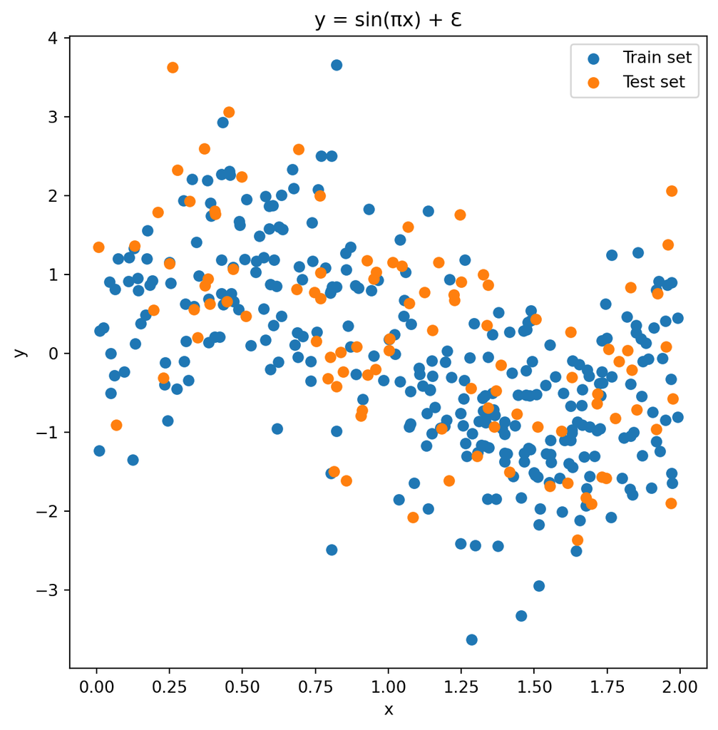

## Ajustes polinomiais

```
Best fit polynomial degree:  3
```

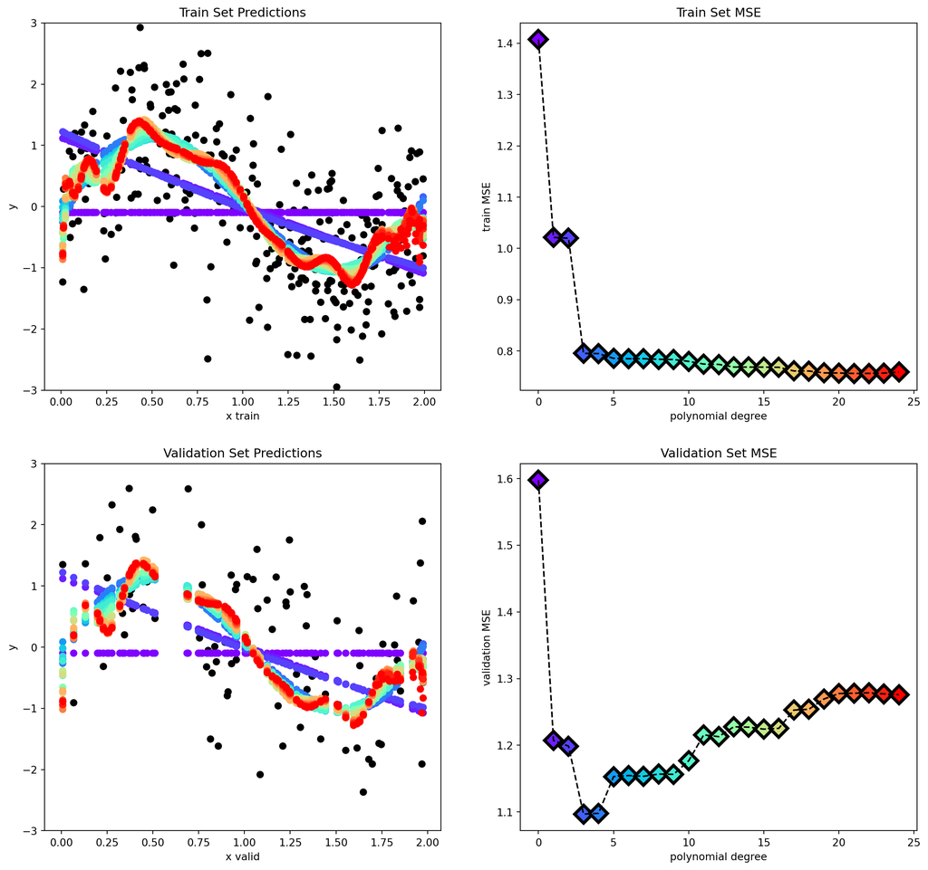